# Risk Factor Analysis

## Outcome Variable

**Outcome Variable:** ever_stunted

## Predictor Variables

**Intervention Variable:** month

**Adjustment Set:**

unadjusted

## Stratifying Variables

The analysis was stratified on these variable(s):

- agecat
- studyid
- country

## Data Summary

| agecat | studyid | country | month | ever_stunted | n_cell | n |
| --- | --- | --- | --- | --- | --- | --- |
| 0-6 months | ki0047075b-MAL-ED | BANGLADESH | 1 | 0 | 17 | 265 |
| 0-6 months | ki0047075b-MAL-ED | BANGLADESH | 1 | 1 | 3 | 265 |
| 0-6 months | ki0047075b-MAL-ED | BANGLADESH | 2 | 0 | 18 | 265 |
| 0-6 months | ki0047075b-MAL-ED | BANGLADESH | 2 | 1 | 6 | 265 |
| 0-6 months | ki0047075b-MAL-ED | BANGLADESH | 3 | 0 | 20 | 265 |
| 0-6 months | ki0047075b-MAL-ED | BANGLADESH | 3 | 1 | 8 | 265 |
| 0-6 months | ki0047075b-MAL-ED | BANGLADESH | 4 | 0 | 22 | 265 |
| 0-6 months | ki0047075b-MAL-ED | BANGLADESH | 4 | 1 | 0 | 265 |
| 0-6 months | ki0047075b-MAL-ED | BANGLADESH | 5 | 0 | 17 | 265 |
| 0-6 months | ki0047075b-MAL-ED | BANGLADESH | 5 | 1 | 5 | 265 |
| 0-6 months | ki0047075b-MAL-ED | BANGLADESH | 6 | 0 | 5 | 265 |
| 0-6 months | ki0047075b-MAL-ED | BANGLADESH | 6 | 1 | 4 | 265 |
| 0-6 months | ki0047075b-MAL-ED | BANGLADESH | 7 | 0 | 17 | 265 |
| 0-6 months | ki0047075b-MAL-ED | BANGLADESH | 7 | 1 | 5 | 265 |
| 0-6 months | ki0047075b-MAL-ED | BANGLADESH | 8 | 0 | 20 | 265 |
| 0-6 months | ki0047075b-MAL-ED | BANGLADESH | 8 | 1 | 5 | 265 |
| 0-6 months | ki0047075b-MAL-ED | BANGLADESH | 9 | 0 | 21 | 265 |
| 0-6 months | ki0047075b-MAL-ED | BANGLADESH | 9 | 1 | 3 | 265 |
| 0-6 months | ki0047075b-MAL-ED | BANGLADESH | 10 | 0 | 19 | 265 |
| 0-6 months | ki0047075b-MAL-ED | BANGLADESH | 10 | 1 | 5 | 265 |
| 0-6 months | ki0047075b-MAL-ED | BANGLADESH | 11 | 0 | 15 | 265 |
| 0-6 months | ki0047075b-MAL-ED | BANGLADESH | 11 | 1 | 2 | 265 |
| 0-6 months | ki0047075b-MAL-ED | BANGLADESH | 12 | 0 | 26 | 265 |
| 0-6 months | ki0047075b-MAL-ED | BANGLADESH | 12 | 1 | 2 | 265 |
| 0-6 months | ki0047075b-MAL-ED | BRAZIL | 1 | 0 | 13 | 233 |
| 0-6 months | ki0047075b-MAL-ED | BRAZIL | 1 | 1 | 0 | 233 |
| 0-6 months | ki0047075b-MAL-ED | BRAZIL | 2 | 0 | 23 | 233 |
| 0-6 months | ki0047075b-MAL-ED | BRAZIL | 2 | 1 | 3 | 233 |
| 0-6 months | ki0047075b-MAL-ED | BRAZIL | 3 | 0 | 19 | 233 |
| 0-6 months | ki0047075b-MAL-ED | BRAZIL | 3 | 1 | 2 | 233 |

[output cut: 1884 more lines]

The following strata were considered:

- agecat: 0-24 months, studyid: ki0047075b-MAL-ED, country: BANGLADESH
- agecat: 0-24 months, studyid: ki0047075b-MAL-ED, country: BRAZIL
- agecat: 0-24 months, studyid: ki0047075b-MAL-ED, country: INDIA
- agecat: 0-24 months, studyid: ki0047075b-MAL-ED, country: NEPAL
- agecat: 0-24 months, studyid: ki0047075b-MAL-ED, country: PERU
- agecat: 0-24 months, studyid: ki0047075b-MAL-ED, country: SOUTH AFRICA
- agecat: 0-24 months, studyid: ki0047075b-MAL-ED, country: TANZANIA, UNITED REPUBLIC OF
- agecat: 0-24 months, studyid: ki1000108-CMC-V-BCS-2002, country: INDIA
- agecat: 0-24 months, studyid: ki1000108-IRC, country: INDIA
- agecat: 0-24 months, studyid: ki1000109-EE, country: PAKISTAN
- agecat: 0-24 months, studyid: ki1000109-ResPak, country: PAKISTAN
- agecat: 0-24 months, studyid: ki1000304b-SAS-CompFeed, country: INDIA
- agecat: 0-24 months, studyid: ki1000304b-SAS-FoodSuppl, country: INDIA
- agecat: 0-24 months, studyid: ki1017093-NIH-Birth, country: BANGLADESH
- agecat: 0-24 months, studyid: ki1066203-TanzaniaChild2, country: TANZANIA, UNITED REPUBLIC OF
- agecat: 0-24 months, studyid: ki1112895-Guatemala BSC, country: GUATEMALA
- agecat: 0-24 months, studyid: ki1112895-iLiNS-Zinc, country: BURKINA FASO
- agecat: 0-24 months, studyid: ki1113344-GMS-Nepal, country: NEPAL
- agecat: 0-24 months, studyid: ki1114097-CMIN, country: BANGLADESH
- agecat: 0-24 months, studyid: ki1114097-CMIN, country: BRAZIL
- agecat: 0-24 months, studyid: ki1114097-CMIN, country: GUINEA-BISSAU
- agecat: 0-24 months, studyid: ki1114097-CMIN, country: PERU
- agecat: 0-24 months, studyid: ki1114097-CONTENT, country: PERU
- agecat: 0-24 months, studyid: ki1119695-PROBIT, country: BELARUS
- agecat: 0-24 months, studyid: ki1126311-ZVITAMBO, country: ZIMBABWE
- agecat: 0-24 months, studyid: ki1148112-LCNI-5, country: MALAWI
- agecat: 0-24 months, studyid: kiGH5241-JiVitA-3, country: BANGLADESH
- agecat: 0-24 months, studyid: kiGH5241-JiVitA-4, country: BANGLADESH
- agecat: 0-6 months, studyid: ki0047075b-MAL-ED, country: BANGLADESH
- agecat: 0-6 months, studyid: ki0047075b-MAL-ED, country: BRAZIL
- agecat: 0-6 months, studyid: ki0047075b-MAL-ED, country: INDIA
- agecat: 0-6 months, studyid: ki0047075b-MAL-ED, country: NEPAL
- agecat: 0-6 months, studyid: ki0047075b-MAL-ED, country: PERU
- agecat: 0-6 months, studyid: ki0047075b-MAL-ED, country: SOUTH AFRICA
- agecat: 0-6 months, studyid: ki0047075b-MAL-ED, country: TANZANIA, UNITED REPUBLIC OF
- agecat: 0-6 months, studyid: ki1000108-CMC-V-BCS-2002, country: INDIA
- agecat: 0-6 months, studyid: ki1000108-IRC, country: INDIA
- agecat: 0-6 months, studyid: ki1000109-EE, country: PAKISTAN
- agecat: 0-6 months, studyid: ki1000109-ResPak, country: PAKISTAN
- agecat: 0-6 months, studyid: ki1000304b-SAS-CompFeed, country: INDIA
- agecat: 0-6 months, studyid: ki1000304b-SAS-FoodSuppl, country: INDIA
- agecat: 0-6 months, studyid: ki1017093-NIH-Birth, country: BANGLADESH
- agecat: 0-6 months, studyid: ki1066203-TanzaniaChild2, country: TANZANIA, UNITED REPUBLIC OF
- agecat: 0-6 months, studyid: ki1112895-Guatemala BSC, country: GUATEMALA
- agecat: 0-6 months, studyid: ki1113344-GMS-Nepal, country: NEPAL
- agecat: 0-6 months, studyid: ki1114097-CMIN, country: BANGLADESH
- agecat: 0-6 months, studyid: ki1114097-CMIN, country: BRAZIL
- agecat: 0-6 months, studyid: ki1114097-CMIN, country: GUINEA-BISSAU
- agecat: 0-6 months, studyid: ki1114097-CMIN, country: PERU
- agecat: 0-6 months, studyid: ki1114097-CONTENT, country: PERU
- agecat: 0-6 months, studyid: ki1119695-PROBIT, country: BELARUS
- agecat: 0-6 months, studyid: ki1126311-ZVITAMBO, country: ZIMBABWE
- agecat: 0-6 months, studyid: ki1148112-LCNI-5, country: MALAWI
- agecat: 0-6 months, studyid: kiGH5241-JiVitA-3, country: BANGLADESH
- agecat: 0-6 months, studyid: kiGH5241-JiVitA-4, country: BANGLADESH
- agecat: 6-24 months, studyid: ki0047075b-MAL-ED, country: BANGLADESH
- agecat: 6-24 months, studyid: ki0047075b-MAL-ED, country: BRAZIL
- agecat: 6-24 months, studyid: ki0047075b-MAL-ED, country: INDIA
- agecat: 6-24 months, studyid: ki0047075b-MAL-ED, country: NEPAL
- agecat: 6-24 months, studyid: ki0047075b-MAL-ED, country: PERU
- agecat: 6-24 months, studyid: ki0047075b-MAL-ED, country: SOUTH AFRICA
- agecat: 6-24 months, studyid: ki0047075b-MAL-ED, country: TANZANIA, UNITED REPUBLIC OF
- agecat: 6-24 months, studyid: ki1000108-CMC-V-BCS-2002, country: INDIA
- agecat: 6-24 months, studyid: ki1000108-IRC, country: INDIA
- agecat: 6-24 months, studyid: ki1000109-EE, country: PAKISTAN
- agecat: 6-24 months, studyid: ki1000109-ResPak, country: PAKISTAN
- agecat: 6-24 months, studyid: ki1000304b-SAS-CompFeed, country: INDIA
- agecat: 6-24 months, studyid: ki1000304b-SAS-FoodSuppl, country: INDIA
- agecat: 6-24 months, studyid: ki1017093-NIH-Birth, country: BANGLADESH
- agecat: 6-24 months, studyid: ki1066203-TanzaniaChild2, country: TANZANIA, UNITED REPUBLIC OF
- agecat: 6-24 months, studyid: ki1112895-Guatemala BSC, country: GUATEMALA
- agecat: 6-24 months, studyid: ki1112895-iLiNS-Zinc, country: BURKINA FASO
- agecat: 6-24 months, studyid: ki1113344-GMS-Nepal, country: NEPAL
- agecat: 6-24 months, studyid: ki1114097-CMIN, country: BANGLADESH
- agecat: 6-24 months, studyid: ki1114097-CMIN, country: BRAZIL
- agecat: 6-24 months, studyid: ki1114097-CMIN, country: GUINEA-BISSAU
- agecat: 6-24 months, studyid: ki1114097-CMIN, country: PERU
- agecat: 6-24 months, studyid: ki1114097-CONTENT, country: PERU
- agecat: 6-24 months, studyid: ki1119695-PROBIT, country: BELARUS
- agecat: 6-24 months, studyid: ki1126311-ZVITAMBO, country: ZIMBABWE
- agecat: 6-24 months, studyid: ki1148112-LCNI-5, country: MALAWI
- agecat: 6-24 months, studyid: kiGH5241-JiVitA-3, country: BANGLADESH
- agecat: 6-24 months, studyid: kiGH5241-JiVitA-4, country: BANGLADESH

### Dropped Strata

Some strata were dropped due to rare outcomes:

- agecat: 0-6 months, studyid: ki0047075b-MAL-ED, country: BANGLADESH
- agecat: 0-6 months, studyid: ki0047075b-MAL-ED, country: BRAZIL
- agecat: 0-6 months, studyid: ki0047075b-MAL-ED, country: INDIA
- agecat: 0-6 months, studyid: ki0047075b-MAL-ED, country: NEPAL
- agecat: 0-6 months, studyid: ki0047075b-MAL-ED, country: PERU
- agecat: 0-6 months, studyid: ki0047075b-MAL-ED, country: SOUTH AFRICA
- agecat: 0-6 months, studyid: ki0047075b-MAL-ED, country: TANZANIA, UNITED REPUBLIC OF
- agecat: 0-6 months, studyid: ki1000108-CMC-V-BCS-2002, country: INDIA
- agecat: 0-6 months, studyid: ki1000108-IRC, country: INDIA
- agecat: 0-6 months, studyid: ki1000109-EE, country: PAKISTAN
- agecat: 0-6 months, studyid: ki1000109-ResPak, country: PAKISTAN
- agecat: 0-6 months, studyid: ki1000304b-SAS-FoodSuppl, country: INDIA
- agecat: 0-6 months, studyid: ki1112895-Guatemala BSC, country: GUATEMALA
- agecat: 0-6 months, studyid: ki1113344-GMS-Nepal, country: NEPAL
- agecat: 0-6 months, studyid: ki1114097-CMIN, country: BANGLADESH
- agecat: 0-6 months, studyid: ki1114097-CMIN, country: BRAZIL
- agecat: 0-6 months, studyid: ki1114097-CMIN, country: GUINEA-BISSAU
- agecat: 0-6 months, studyid: ki1114097-CMIN, country: PERU
- agecat: 0-6 months, studyid: ki1114097-CONTENT, country: PERU
- agecat: 0-6 months, studyid: ki1148112-LCNI-5, country: MALAWI
- agecat: 6-24 months, studyid: ki0047075b-MAL-ED, country: BANGLADESH
- agecat: 6-24 months, studyid: ki0047075b-MAL-ED, country: BRAZIL
- agecat: 6-24 months, studyid: ki0047075b-MAL-ED, country: INDIA
- agecat: 6-24 months, studyid: ki0047075b-MAL-ED, country: NEPAL
- agecat: 6-24 months, studyid: ki0047075b-MAL-ED, country: PERU
- agecat: 6-24 months, studyid: ki0047075b-MAL-ED, country: SOUTH AFRICA
- agecat: 6-24 months, studyid: ki0047075b-MAL-ED, country: TANZANIA, UNITED REPUBLIC OF
- agecat: 6-24 months, studyid: ki1000108-CMC-V-BCS-2002, country: INDIA
- agecat: 6-24 months, studyid: ki1000108-IRC, country: INDIA
- agecat: 6-24 months, studyid: ki1000109-EE, country: PAKISTAN
- agecat: 6-24 months, studyid: ki1000109-ResPak, country: PAKISTAN
- agecat: 6-24 months, studyid: ki1000304b-SAS-FoodSuppl, country: INDIA
- agecat: 6-24 months, studyid: ki1112895-Guatemala BSC, country: GUATEMALA
- agecat: 6-24 months, studyid: ki1113344-GMS-Nepal, country: NEPAL
- agecat: 6-24 months, studyid: ki1114097-CMIN, country: BANGLADESH
- agecat: 6-24 months, studyid: ki1114097-CMIN, country: BRAZIL
- agecat: 6-24 months, studyid: ki1114097-CONTENT, country: PERU
- agecat: 6-24 months, studyid: ki1148112-LCNI-5, country: MALAWI
- agecat: 0-24 months, studyid: ki0047075b-MAL-ED, country: BANGLADESH
- agecat: 0-24 months, studyid: ki0047075b-MAL-ED, country: BRAZIL
- agecat: 0-24 months, studyid: ki0047075b-MAL-ED, country: INDIA
- agecat: 0-24 months, studyid: ki0047075b-MAL-ED, country: NEPAL
- agecat: 0-24 months, studyid: ki0047075b-MAL-ED, country: SOUTH AFRICA
- agecat: 0-24 months, studyid: ki0047075b-MAL-ED, country: TANZANIA, UNITED REPUBLIC OF
- agecat: 0-24 months, studyid: ki1000108-CMC-V-BCS-2002, country: INDIA
- agecat: 0-24 months, studyid: ki1000109-EE, country: PAKISTAN
- agecat: 0-24 months, studyid: ki1000109-ResPak, country: PAKISTAN
- agecat: 0-24 months, studyid: ki1000304b-SAS-FoodSuppl, country: INDIA
- agecat: 0-24 months, studyid: ki1113344-GMS-Nepal, country: NEPAL
- agecat: 0-24 months, studyid: ki1114097-CMIN, country: BANGLADESH
- agecat: 0-24 months, studyid: ki1114097-CMIN, country: BRAZIL
- agecat: 0-24 months, studyid: ki1114097-CONTENT, country: PERU

## Methods Detail

We’re interested in the causal parameters $E[Y_a]$ for all values of $a \in \mathcal{A}$. These parameters represent the mean outcome if, possibly contrary to fact, we intervened to set all units to have $A=a$. Under the randomization and positivity assumptions, these are identified by the statistical parameters $\psi_a=E_W[E_{Y|A,W}(Y|A=a,W)]$. In addition, we’re interested in the mean of $Y$, $E[Y]$ under no intervention (the observed mean). We will estimate these parameters by using SuperLearner to fit the relevant likelihood factors – $E_{Y|A,W}(Y|A=a,W)$ and $p(A=a|W)$, and then updating our likelihood fit using a joint TMLE.

For unadjusted analyses ($W=\{\}$), initial likelihoods were estimated using Lrnr_glm to estimate the simple $E(Y|A)$ and Lrnr_mean to estimate $p(A)$. For adjusted analyses, a small library containing Lrnr_glmnet, Lrnr_xgboost, and Lrnr_mean was used.

Having estimated these parameters, we will then use the delta method to estimate relative risks and attributable risks relative to a prespecified baseline level of $A$.

# Results Detail

## Results Plots

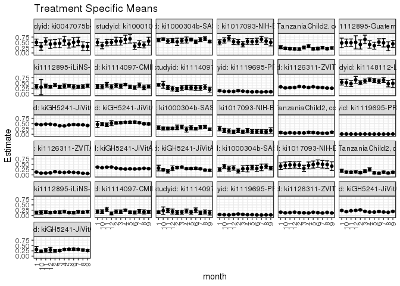

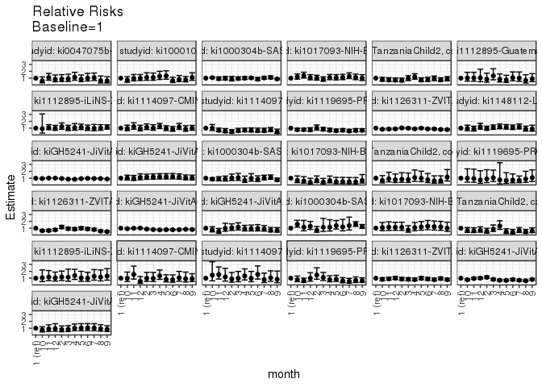

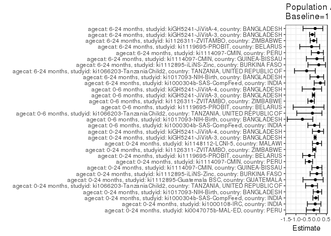

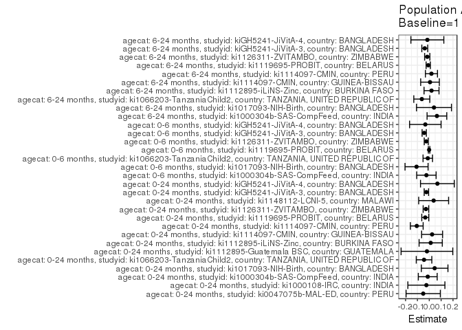

## Results Table

### Parameter: TSM

| agecat | studyid | country | intervention_level | baseline_level | estimate | ci_lower | ci_upper |
| --- | --- | --- | --- | --- | --- | --- | --- |
| 0-24 months | ki0047075b-MAL-ED | PERU | 1 | NA | 0.5000000 | 0.3447949 | 0.6552051 |
| 0-24 months | ki0047075b-MAL-ED | PERU | 2 | NA | 0.4400000 | 0.2450980 | 0.6349020 |
| 0-24 months | ki0047075b-MAL-ED | PERU | 3 | NA | 0.4545455 | 0.2461335 | 0.6629574 |
| 0-24 months | ki0047075b-MAL-ED | PERU | 4 | NA | 0.5714286 | 0.3594222 | 0.7834349 |
| 0-24 months | ki0047075b-MAL-ED | PERU | 5 | NA | 0.4230769 | 0.2328606 | 0.6132933 |
| 0-24 months | ki0047075b-MAL-ED | PERU | 6 | NA | 0.5000000 | 0.2805069 | 0.7194931 |
| 0-24 months | ki0047075b-MAL-ED | PERU | 7 | NA | 0.5416667 | 0.3419947 | 0.7413386 |
| 0-24 months | ki0047075b-MAL-ED | PERU | 8 | NA | 0.3157895 | 0.1064347 | 0.5251442 |
| 0-24 months | ki0047075b-MAL-ED | PERU | 9 | NA | 0.3043478 | 0.1159902 | 0.4927054 |
| 0-24 months | ki0047075b-MAL-ED | PERU | 10 | NA | 0.3076923 | 0.1299924 | 0.4853922 |
| 0-24 months | ki0047075b-MAL-ED | PERU | 11 | NA | 0.5454545 | 0.3752869 | 0.7156222 |
| 0-24 months | ki0047075b-MAL-ED | PERU | 12 | NA | 0.4166667 | 0.2191003 | 0.6142331 |
| 0-24 months | ki1000108-IRC | INDIA | 1 | NA | 0.5000000 | 0.3364701 | 0.6635299 |
| 0-24 months | ki1000108-IRC | INDIA | 2 | NA | 0.5555556 | 0.3678967 | 0.7432144 |
| 0-24 months | ki1000108-IRC | INDIA | 3 | NA | 0.5517241 | 0.3705013 | 0.7329470 |
| 0-24 months | ki1000108-IRC | INDIA | 4 | NA | 0.6363636 | 0.4351055 | 0.8376217 |
| 0-24 months | ki1000108-IRC | INDIA | 5 | NA | 0.6666667 | 0.4648010 | 0.8685323 |
| 0-24 months | ki1000108-IRC | INDIA | 6 | NA | 0.3243243 | 0.1733036 | 0.4753450 |
| 0-24 months | ki1000108-IRC | INDIA | 7 | NA | 0.4166667 | 0.2554240 | 0.5779093 |
| 0-24 months | ki1000108-IRC | INDIA | 8 | NA | 0.3777778 | 0.2359494 | 0.5196061 |
| 0-24 months | ki1000108-IRC | INDIA | 9 | NA | 0.5555556 | 0.3678967 | 0.7432144 |
| 0-24 months | ki1000108-IRC | INDIA | 10 | NA | 0.3513514 | 0.1973399 | 0.5053628 |
| 0-24 months | ki1000108-IRC | INDIA | 11 | NA | 0.4878049 | 0.3346160 | 0.6409938 |
| 0-24 months | ki1000108-IRC | INDIA | 12 | NA | 0.5000000 | 0.3639349 | 0.6360651 |
| 0-24 months | ki1000304b-SAS-CompFeed | INDIA | 1 | NA | 0.6071429 | 0.5252734 | 0.6890123 |
| 0-24 months | ki1000304b-SAS-CompFeed | INDIA | 2 | NA | 0.5268817 | 0.3569367 | 0.6968267 |
| 0-24 months | ki1000304b-SAS-CompFeed | INDIA | 3 | NA | 0.5777778 | 0.4628351 | 0.6927205 |
| 0-24 months | ki1000304b-SAS-CompFeed | INDIA | 4 | NA | 0.6097561 | 0.4674441 | 0.7520681 |
| 0-24 months | ki1000304b-SAS-CompFeed | INDIA | 5 | NA | 0.6304348 | 0.5665746 | 0.6942950 |
| 0-24 months | ki1000304b-SAS-CompFeed | INDIA | 6 | NA | 0.5217391 | 0.4363537 | 0.6071246 |

[output cut: 342 more lines]

### Parameter: E(Y)

| agecat | studyid | country | intervention_level | baseline_level | estimate | ci_lower | ci_upper |
| --- | --- | --- | --- | --- | --- | --- | --- |
| 0-24 months | ki0047075b-MAL-ED | PERU | NA | NA | 0.4488449 | 0.3927492 | 0.5049406 |
| 0-24 months | ki1000108-IRC | INDIA | NA | NA | 0.4756098 | 0.4272105 | 0.5240091 |
| 0-24 months | ki1000304b-SAS-CompFeed | INDIA | NA | NA | 0.5942596 | 0.5539147 | 0.6346046 |
| 0-24 months | ki1017093-NIH-Birth | BANGLADESH | NA | NA | 0.5453100 | 0.5063654 | 0.5842547 |
| 0-24 months | ki1066203-TanzaniaChild2 | TANZANIA, UNITED REPUBLIC OF | NA | NA | 0.2257930 | 0.2090482 | 0.2425378 |
| 0-24 months | ki1112895-Guatemala BSC | GUATEMALA | NA | NA | 0.4539683 | 0.3988995 | 0.5090370 |
| 0-24 months | ki1112895-iLiNS-Zinc | BURKINA FASO | NA | NA | 0.3384380 | 0.2882099 | 0.3886661 |
| 0-24 months | ki1114097-CMIN | GUINEA-BISSAU | NA | NA | 0.3636364 | 0.3393411 | 0.3879316 |
| 0-24 months | ki1114097-CMIN | PERU | NA | NA | 0.3057051 | 0.2760637 | 0.3353464 |
| 0-24 months | ki1119695-PROBIT | BELARUS | NA | NA | 0.1006096 | 0.0848963 | 0.1163228 |
| 0-24 months | ki1126311-ZVITAMBO | ZIMBABWE | NA | NA | 0.2925683 | 0.2850450 | 0.3000917 |
| 0-24 months | ki1148112-LCNI-5 | MALAWI | NA | NA | 0.5726190 | 0.5391450 | 0.6060930 |
| 0-24 months | kiGH5241-JiVitA-3 | BANGLADESH | NA | NA | 0.4437509 | 0.4362402 | 0.4512616 |
| 0-24 months | kiGH5241-JiVitA-4 | BANGLADESH | NA | NA | 0.5316060 | 0.5154292 | 0.5477829 |
| 0-6 months | ki1000304b-SAS-CompFeed | INDIA | NA | NA | 0.2882353 | 0.2618269 | 0.3146436 |
| 0-6 months | ki1017093-NIH-Birth | BANGLADESH | NA | NA | 0.1573927 | 0.1289105 | 0.1858749 |
| 0-6 months | ki1066203-TanzaniaChild2 | TANZANIA, UNITED REPUBLIC OF | NA | NA | 0.0671953 | 0.0571686 | 0.0772221 |
| 0-6 months | ki1119695-PROBIT | BELARUS | NA | NA | 0.0090570 | 0.0059070 | 0.0122070 |
| 0-6 months | ki1126311-ZVITAMBO | ZIMBABWE | NA | NA | 0.1053757 | 0.1002943 | 0.1104572 |
| 0-6 months | kiGH5241-JiVitA-3 | BANGLADESH | NA | NA | 0.3218623 | 0.3151120 | 0.3286127 |
| 0-6 months | kiGH5241-JiVitA-4 | BANGLADESH | NA | NA | 0.2867446 | 0.2729319 | 0.3005573 |
| 6-24 months | ki1000304b-SAS-CompFeed | INDIA | NA | NA | 0.3184647 | 0.2882909 | 0.3486385 |
| 6-24 months | ki1017093-NIH-Birth | BANGLADESH | NA | NA | 0.4500000 | 0.4023647 | 0.4976353 |
| 6-24 months | ki1066203-TanzaniaChild2 | TANZANIA, UNITED REPUBLIC OF | NA | NA | 0.1337304 | 0.1182039 | 0.1492569 |
| 6-24 months | ki1112895-iLiNS-Zinc | BURKINA FASO | NA | NA | 0.1527830 | 0.1267871 | 0.1787788 |
| 6-24 months | ki1114097-CMIN | GUINEA-BISSAU | NA | NA | 0.1901352 | 0.1684337 | 0.2118368 |
| 6-24 months | ki1114097-CMIN | PERU | NA | NA | 0.1755319 | 0.1483241 | 0.2027397 |
| 6-24 months | ki1119695-PROBIT | BELARUS | NA | NA | 0.0380298 | 0.0285924 | 0.0474672 |
| 6-24 months | ki1126311-ZVITAMBO | ZIMBABWE | NA | NA | 0.1360361 | 0.1290678 | 0.1430045 |
| 6-24 months | kiGH5241-JiVitA-3 | BANGLADESH | NA | NA | 0.1970836 | 0.1890247 | 0.2051424 |
| 6-24 months | kiGH5241-JiVitA-4 | BANGLADESH | NA | NA | 0.2949907 | 0.2786334 | 0.3113480 |

### Parameter: RR

| agecat | studyid | country | intervention_level | baseline_level | estimate | ci_lower | ci_upper |
| --- | --- | --- | --- | --- | --- | --- | --- |
| 0-24 months | ki0047075b-MAL-ED | PERU | 1 | 1 | 1.0000000 | 1.0000000 | 1.0000000 |
| 0-24 months | ki0047075b-MAL-ED | PERU | 2 | 1 | 0.8800000 | 0.5123598 | 1.5114379 |
| 0-24 months | ki0047075b-MAL-ED | PERU | 3 | 1 | 0.9090909 | 0.5225634 | 1.5815236 |
| 0-24 months | ki0047075b-MAL-ED | PERU | 4 | 1 | 1.1428571 | 0.7045416 | 1.8538614 |
| 0-24 months | ki0047075b-MAL-ED | PERU | 5 | 1 | 0.8461538 | 0.4899742 | 1.4612532 |
| 0-24 months | ki0047075b-MAL-ED | PERU | 6 | 1 | 1.0000000 | 0.5841216 | 1.7119724 |
| 0-24 months | ki0047075b-MAL-ED | PERU | 7 | 1 | 1.0833333 | 0.6690683 | 1.7540976 |
| 0-24 months | ki0047075b-MAL-ED | PERU | 8 | 1 | 0.6315789 | 0.3037467 | 1.3132388 |
| 0-24 months | ki0047075b-MAL-ED | PERU | 9 | 1 | 0.6086957 | 0.3045840 | 1.2164475 |
| 0-24 months | ki0047075b-MAL-ED | PERU | 10 | 1 | 0.6153846 | 0.3194460 | 1.1854845 |
| 0-24 months | ki0047075b-MAL-ED | PERU | 11 | 1 | 1.0909091 | 0.7025196 | 1.6940207 |
| 0-24 months | ki0047075b-MAL-ED | PERU | 12 | 1 | 0.8333333 | 0.4728153 | 1.4687435 |
| 0-24 months | ki1000108-IRC | INDIA | 1 | 1 | 1.0000000 | 1.0000000 | 1.0000000 |
| 0-24 months | ki1000108-IRC | INDIA | 2 | 1 | 1.1111111 | 0.6943233 | 1.7780879 |
| 0-24 months | ki1000108-IRC | INDIA | 3 | 1 | 1.1034483 | 0.6941355 | 1.7541215 |
| 0-24 months | ki1000108-IRC | INDIA | 4 | 1 | 1.2727273 | 0.8075101 | 2.0059621 |
| 0-24 months | ki1000108-IRC | INDIA | 5 | 1 | 1.3333333 | 0.8538282 | 2.0821258 |
| 0-24 months | ki1000108-IRC | INDIA | 6 | 1 | 0.6486486 | 0.3671833 | 1.1458721 |
| 0-24 months | ki1000108-IRC | INDIA | 7 | 1 | 0.8333333 | 0.5020777 | 1.3831413 |
| 0-24 months | ki1000108-IRC | INDIA | 8 | 1 | 0.7555556 | 0.4592264 | 1.2430996 |
| 0-24 months | ki1000108-IRC | INDIA | 9 | 1 | 1.1111111 | 0.6943233 | 1.7780879 |
| 0-24 months | ki1000108-IRC | INDIA | 10 | 1 | 0.7027027 | 0.4066790 | 1.2142037 |
| 0-24 months | ki1000108-IRC | INDIA | 11 | 1 | 0.9756098 | 0.6199539 | 1.5352986 |
| 0-24 months | ki1000108-IRC | INDIA | 12 | 1 | 1.0000000 | 0.6534640 | 1.5303063 |
| 0-24 months | ki1000304b-SAS-CompFeed | INDIA | 1 | 1 | 1.0000000 | 1.0000000 | 1.0000000 |
| 0-24 months | ki1000304b-SAS-CompFeed | INDIA | 2 | 1 | 0.8678052 | 0.6002048 | 1.2547147 |
| 0-24 months | ki1000304b-SAS-CompFeed | INDIA | 3 | 1 | 0.9516340 | 0.7612219 | 1.1896757 |
| 0-24 months | ki1000304b-SAS-CompFeed | INDIA | 4 | 1 | 1.0043042 | 0.8160801 | 1.2359410 |
| 0-24 months | ki1000304b-SAS-CompFeed | INDIA | 5 | 1 | 1.0383632 | 0.9063821 | 1.1895624 |
| 0-24 months | ki1000304b-SAS-CompFeed | INDIA | 6 | 1 | 0.8593350 | 0.6732413 | 1.0968677 |

[output cut: 342 more lines]

### Parameter: PAR

| agecat | studyid | country | intervention_level | baseline_level | estimate | ci_lower | ci_upper |
| --- | --- | --- | --- | --- | --- | --- | --- |
| 0-24 months | ki0047075b-MAL-ED | PERU | 1 | NA | -0.0511551 | -0.1956380 | 0.0933278 |
| 0-24 months | ki1000108-IRC | INDIA | 1 | NA | -0.0243902 | -0.1805580 | 0.1317775 |
| 0-24 months | ki1000304b-SAS-CompFeed | INDIA | 1 | NA | -0.0128832 | -0.0924427 | 0.0666762 |
| 0-24 months | ki1017093-NIH-Birth | BANGLADESH | 1 | NA | 0.0453100 | -0.0669562 | 0.1575762 |
| 0-24 months | ki1066203-TanzaniaChild2 | TANZANIA, UNITED REPUBLIC OF | 1 | NA | -0.0441457 | -0.1096787 | 0.0213874 |
| 0-24 months | ki1112895-Guatemala BSC | GUATEMALA | 1 | NA | -0.0197160 | -0.2376576 | 0.1982257 |
| 0-24 months | ki1112895-iLiNS-Zinc | BURKINA FASO | 1 | NA | 0.0120781 | -0.0858545 | 0.1100108 |
| 0-24 months | ki1114097-CMIN | GUINEA-BISSAU | 1 | NA | 0.0238305 | -0.0645900 | 0.1122511 |
| 0-24 months | ki1114097-CMIN | PERU | 1 | NA | -0.1055504 | -0.1594470 | -0.0516537 |
| 0-24 months | ki1119695-PROBIT | BELARUS | 1 | NA | -0.0337329 | -0.0632736 | -0.0041922 |
| 0-24 months | ki1126311-ZVITAMBO | ZIMBABWE | 1 | NA | -0.0281314 | -0.0515291 | -0.0047336 |
| 0-24 months | ki1148112-LCNI-5 | MALAWI | 1 | NA | 0.0369048 | -0.0892899 | 0.1630994 |
| 0-24 months | kiGH5241-JiVitA-3 | BANGLADESH | 1 | NA | -0.0242351 | -0.0426858 | -0.0057844 |
| 0-24 months | kiGH5241-JiVitA-4 | BANGLADESH | 1 | NA | 0.0686431 | -0.0739047 | 0.2111908 |
| 0-6 months | ki1000304b-SAS-CompFeed | INDIA | 1 | NA | -0.0242647 | -0.1061387 | 0.0576093 |
| 0-6 months | ki1017093-NIH-Birth | BANGLADESH | 1 | NA | -0.1073132 | -0.2044883 | -0.0101381 |
| 0-6 months | ki1066203-TanzaniaChild2 | TANZANIA, UNITED REPUBLIC OF | 1 | NA | -0.0125593 | -0.0525031 | 0.0273845 |
| 0-6 months | ki1119695-PROBIT | BELARUS | 1 | NA | -0.0013597 | -0.0077642 | 0.0050449 |
| 0-6 months | ki1126311-ZVITAMBO | ZIMBABWE | 1 | NA | -0.0254722 | -0.0422918 | -0.0086526 |
| 0-6 months | kiGH5241-JiVitA-3 | BANGLADESH | 1 | NA | -0.0427291 | -0.0605722 | -0.0248860 |
| 0-6 months | kiGH5241-JiVitA-4 | BANGLADESH | 1 | NA | -0.0332554 | -0.1660611 | 0.0995504 |
| 6-24 months | ki1000304b-SAS-CompFeed | INDIA | 1 | NA | 0.0644965 | -0.0185366 | 0.1475295 |
| 6-24 months | ki1017093-NIH-Birth | BANGLADESH | 1 | NA | 0.0397436 | -0.1076370 | 0.1871242 |
| 6-24 months | ki1066203-TanzaniaChild2 | TANZANIA, UNITED REPUBLIC OF | 1 | NA | -0.0629909 | -0.1305320 | 0.0045501 |
| 6-24 months | ki1112895-iLiNS-Zinc | BURKINA FASO | 1 | NA | 0.0191196 | -0.0438709 | 0.0821101 |
| 6-24 months | ki1114097-CMIN | GUINEA-BISSAU | 1 | NA | 0.0062272 | -0.0724186 | 0.0848730 |
| 6-24 months | ki1114097-CMIN | PERU | 1 | NA | 0.0182992 | -0.0325966 | 0.0691950 |
| 6-24 months | ki1119695-PROBIT | BELARUS | 1 | NA | -0.0086435 | -0.0265800 | 0.0092931 |
| 6-24 months | ki1126311-ZVITAMBO | ZIMBABWE | 1 | NA | -0.0169693 | -0.0390059 | 0.0050673 |
| 6-24 months | kiGH5241-JiVitA-3 | BANGLADESH | 1 | NA | -0.0380412 | -0.0628909 | -0.0131914 |
| 6-24 months | kiGH5241-JiVitA-4 | BANGLADESH | 1 | NA | -0.0161204 | -0.1549673 | 0.1227266 |

### Parameter: PAF

| agecat | studyid | country | intervention_level | baseline_level | estimate | ci_lower | ci_upper |
| --- | --- | --- | --- | --- | --- | --- | --- |
| 0-24 months | ki0047075b-MAL-ED | PERU | 1 | NA | -0.1139706 | -0.4875447 | 0.1657861 |
| 0-24 months | ki1000108-IRC | INDIA | 1 | NA | -0.0512821 | -0.4367471 | 0.2307666 |
| 0-24 months | ki1000304b-SAS-CompFeed | INDIA | 1 | NA | -0.0216795 | -0.1650640 | 0.1040587 |
| 0-24 months | ki1017093-NIH-Birth | BANGLADESH | 1 | NA | 0.0830904 | -0.1478583 | 0.2675723 |
| 0-24 months | ki1066203-TanzaniaChild2 | TANZANIA, UNITED REPUBLIC OF | 1 | NA | -0.1955139 | -0.5238720 | 0.0620909 |
| 0-24 months | ki1112895-Guatemala BSC | GUATEMALA | 1 | NA | -0.0434303 | -0.6530680 | 0.3413782 |
| 0-24 months | ki1112895-iLiNS-Zinc | BURKINA FASO | 1 | NA | 0.0356879 | -0.3011456 | 0.2853238 |
| 0-24 months | ki1114097-CMIN | GUINEA-BISSAU | 1 | NA | 0.0655340 | -0.2121938 | 0.2796311 |
| 0-24 months | ki1114097-CMIN | PERU | 1 | NA | -0.3452686 | -0.5343139 | -0.1795159 |
| 0-24 months | ki1119695-PROBIT | BELARUS | 1 | NA | -0.3352852 | -0.6682225 | -0.0687943 |
| 0-24 months | ki1126311-ZVITAMBO | ZIMBABWE | 1 | NA | -0.0961532 | -0.1791125 | -0.0190306 |
| 0-24 months | ki1148112-LCNI-5 | MALAWI | 1 | NA | 0.0644491 | -0.1841148 | 0.2608356 |
| 0-24 months | kiGH5241-JiVitA-3 | BANGLADESH | 1 | NA | -0.0546142 | -0.0970479 | -0.0138219 |
| 0-24 months | kiGH5241-JiVitA-4 | BANGLADESH | 1 | NA | 0.1291239 | -0.1850803 | 0.3600222 |
| 0-6 months | ki1000304b-SAS-CompFeed | INDIA | 1 | NA | -0.0841837 | -0.4103088 | 0.1665270 |
| 0-6 months | ki1017093-NIH-Birth | BANGLADESH | 1 | NA | -0.6818182 | -1.4211589 | -0.1682473 |
| 0-6 months | ki1066203-TanzaniaChild2 | TANZANIA, UNITED REPUBLIC OF | 1 | NA | -0.1869070 | -0.9576158 | 0.2803756 |
| 0-6 months | ki1119695-PROBIT | BELARUS | 1 | NA | -0.1501225 | -1.1323572 | 0.3796622 |
| 0-6 months | ki1126311-ZVITAMBO | ZIMBABWE | 1 | NA | -0.2417276 | -0.4117130 | -0.0922103 |
| 0-6 months | kiGH5241-JiVitA-3 | BANGLADESH | 1 | NA | -0.1327558 | -0.1895801 | -0.0786459 |
| 0-6 months | kiGH5241-JiVitA-4 | BANGLADESH | 1 | NA | -0.1159755 | -0.6900119 | 0.2630813 |
| 6-24 months | ki1000304b-SAS-CompFeed | INDIA | 1 | NA | 0.2025231 | -0.0997123 | 0.4216948 |
| 6-24 months | ki1017093-NIH-Birth | BANGLADESH | 1 | NA | 0.0883191 | -0.3058405 | 0.3635041 |
| 6-24 months | ki1066203-TanzaniaChild2 | TANZANIA, UNITED REPUBLIC OF | 1 | NA | -0.4710294 | -1.0713397 | -0.0446995 |
| 6-24 months | ki1112895-iLiNS-Zinc | BURKINA FASO | 1 | NA | 0.1251422 | -0.4070003 | 0.4560228 |
| 6-24 months | ki1114097-CMIN | GUINEA-BISSAU | 1 | NA | 0.0327514 | -0.4833858 | 0.3693011 |
| 6-24 months | ki1114097-CMIN | PERU | 1 | NA | 0.1042500 | -0.2377462 | 0.3517508 |
| 6-24 months | ki1119695-PROBIT | BELARUS | 1 | NA | -0.2272816 | -0.8108958 | 0.1682458 |
| 6-24 months | ki1126311-ZVITAMBO | ZIMBABWE | 1 | NA | -0.1247414 | -0.2988843 | 0.0260541 |
| 6-24 months | kiGH5241-JiVitA-3 | BANGLADESH | 1 | NA | -0.1930205 | -0.3265300 | -0.0729482 |
| 6-24 months | kiGH5241-JiVitA-4 | BANGLADESH | 1 | NA | -0.0546471 | -0.6478686 | 0.3250187 |